# **Mental Health in the Workplace - Week One Project Code**

*Course*: DS 4002 - Data Science Project Course

*Authors*: Navya Annapareddy, Tony Albini, Kunaal Sarnaik, & Jaya Vellayan

*Professor*: Brian Wright

*Date*: January 8th, 2021

## **I. Introduction**

### *a) Motivation*

According to the National Institute of Mental Health, approximately one in five adults live with a mental illness in the United States; this drastic proportion corresponded to a quantity of nearly 51.1 million citizens in 2019.$^{1}$ Although the proportion of adults who experience a mental illness on the global scale is smaller (1 in 17, according to the World Health Organization in 2017), it still roughly equals an astounding magnitude of approximately half a million people.$^{2}$ Despite these monstrous statistics related to mental illness incidence and prevalence, previous studies have shown that only a small percentage of adults who suffer from a mental illness actually receive treatment for it.$^{3}$ For example, the National Institute of Mental Health found that a mere 43.8% of United States adults who were diagnosed with a mental illness actually treatment for it.$^{3}$

Given that incidences of mental illness not only have skyrocketed since the turn of the century, but also are expected to continue increasing at an alarming rate, strategies for addressing, coping with, and treating mental illnesses on the individual level must be developed urgently.$^{4}$ However, when it comes to addressing mental illnesses, one devastating obstacle looms large both individually and societally — the stigma against them. According to the American Psychiatric Association (APA), three types of stigmas govern the mental illness conversation$^{5}$:

> **1. Public Stigma**: negative or discriminatory attitudes that others have about mental illness.

> **2. Self-stigma**: negative attitudes, including internalized shame, that people with mental illness have about their own condition.

> **3. Institutional Stigma**: more systemic, involving policies of government and private organizations that intentionally or unintentionally limit opportunities for people with mental illness.

A unique location where all three of these stigmas are practiced extensively is the workplace, where the APA has found that more than one in three workers are concerned about being fired if they sought mental health care.$^{6}$ The combination of these challenges makes an already difficult act of talking about mental illness much more arduous for workers, who comprise a large proportion of mental illness cases on the global scale.$^{7,8}$ Moreover, such expression regarding one's experience with a mental illness is largely considered to be among first steps towards treatment, and the lack of doing so may only exacerbate the symptoms of a mental illness on the individual.$^{7}$ Furthermore, in the workplace, poor mental health and stress can be detrimental for an employee's job performance, work engagement, communication with coworkers, physical capability, and ability to carry out day-to-day functions.$^{9}$

In a study conducted by the Center for Disease Control, only 57% of employees who reported suffering from moderate depression, in addition to a mere 40% of those who reported suffering from severe depression, received treatment to control their symptoms.$^{9}$ These appalling statistics, combined with the trend that mental health is only becoming harder to manage due to the current COVID-19 pandemic, suggest that finding strategies to increase the likelihood of employees' expressing their experience with mental illnesses to others in order to receive treatment (a mere 55% in 2019, according to a 2021 study) is an urgent priority for not only the nation, but also the world.$^{10}$

The following research project deploys data science and machine learning principles to investigate which factors present in the workplace are the strongest determinants of whether or not an employee confides to their direct supervisor(s).

### *b) Background*

The Mayo Clinic defines mental illnesses, which are also known as mental health disorders, as those that affect one's mood, thinking, and behavior.$^{11}$ Examples of these types of psychological afflictions include depression, anxiety, schizophrenia, bipolar, eating disorders, and addictive behaviors, yet the term mental illness is often used to refer to any among a wide range of mental health conditions. Common symptoms of a mental illness can vary and depend on the disorder; examples, however, include dysphoric mood, avolition, withdrawal from activities, suicidal thinking, and substance abuse.

Although the outcomes of one suffering from a mental illness can be just as debilitating as those of one suffering from any other physical illness such as cancer, stigmatization of those who suffer from them forms a pervasive barrier that prevents many of those suffering from such illnesses to get better.$^{12}$ Since contact with persons with mental illnesses is currently the most well-supported way to reduce stigma, identifying methods to increase such contact in the workplace — an environment that is almost universal to all who share this planet — is an urgent priority. However, for such contact to take place, modern workplace culture must be analyzed.

According to a 2019 survey conducted by Mind Share Partners' Mental Health at Work, 37% of workers reported that their work environment contributed to their mental health symptoms.$^{13}$ Due to a combination of cultural stigma, a lack of understanding of symptoms, increased pressure, and a lack of resources, the current state of the workplace can not only cause mental illnesses, but also further exacerbate existing ones.$^{14}$ Therefore, to gain an understanding of why an insufficient amount of contact with those suffering from mental health disorders occurs in today's workplace, an in-depth analysis of the factors contributing to an employee's willingness to discuss mental health problems with their direct supervisor may be enlightening. After all, the workplace, whether it be online or in-person, is comprising an increasing amount of any person's time, and finding ways to decrease mental health stigma can lead to invaluable returns with respect to not only addressing the illness, but also helping the sufferer of the illness access resources that will alleviate its symptoms.

### *c) General Research Question*

An in-depth analysis utilizing data science and machine learning principles will be conducted in an attempt to address the following research question:

> **What are the strongest predictors dictating whether or not an employee will discuss mental health concerns with their direct supervisor(s)?**

Using this question as a guide, hypotheses will be developed and an extensive and comprehensive analysis that leverages state-of-the-art machine learning techniques will be conducted. A dataset containing responses to a survey administered to employees in the technological industry — one that is largely predicted to sustain the most growth in the near future — will be analyzed (See Dataset Overview & Cleaning section for more information).$^{15}$ The data will be cleaned, exploratory data analysis will be conducted, and then machine learning techniques will be applied in order to determine the strongest predictors of the discrete response variable.

### *d) Relevant Research*

Several studies related to predicting outcomes and behavior related to mental health in the workplace have been previously conducted. For example, a team from the Keio University School of Medicine in Japan, Sado et al., analyzed predictors of repeated sick leave in the workplace as a result of mental disorders.$^{16}$ The Japanese researchers utilized Return To Work (RTW) and repeated sick leave rtes among 194 subjects employed at a manufacturing company. The independent variables of interest included sex, age at the time of employment, job tenure, diagnosis, number of previous sick leave days, duration of most recent sick leave, and employee rank. After conducting a univariate analysis using log-rank test and multivariate analysis using the Cox proportional hazard model, Sado et al. found that the employees' **ages** and **number of previous sick-leave episodes** were a significant predictor of repeated sick leave due to a mental ilness.

Moreover, the Center for Disease Control (CDC) annually conducts a "Mental Health in the Workplace" study, which is included as a sub-section in their Workplace Health Guide.$^{9}$ This study tracks mental illness solutions, frameworks to raise mental health awareness, and useful strategies to tackle the problem. Historically, the CDC has pointed to three key indicators and risk factors of mental illness: **stigma**, **lack of health care**, and **lack of social connections**. Furthermore, they have repeatedly suggested that employers should offer several mental health benefits (e.g., health insurance with no or low out-of-pocket costs, free clinical screenings, and informational brochures), be flexible with sick leave specifically with respect to mental illnesses, and provide managers with training to help recognize signs and symptoms of common mental health disorders.

According to studies consolidated by Harvard Health, the most debilitating characteristic of mental health disorders is that most go unrecognized and untreated due to the stigma attached to them.$^{17}$ Due to such stigma, employees in the workplace feel extremely reluctant to seek treatment out of feat that they might jeapardize their jobs, further exacerbating their already limited ability to communicate their feelings to co-workers. Similarly, the transition towards remote working, whether it be due to the rise of the technological industry or the coercion of the COVID-19 pandemic, may exacerbate feelings of isolation and loneliness, according to the Center for Workplace Mental Health.$^{18}$ Moreover, the remote transitions can have a debilitating affect on the amount of people in a person's social circle, which can also further exacerbate their ability to reach out for help.

In summary, the combination of previous research related to the General Research Question points to several common themes that may affect the likelihood of an employee to reach out to their direct supervisor to discuss a mental health issue: the community, stigmatization, and resources present at the workplace itself.

### *e) Initial Hypotheses*

**Null Hypothesis:** Using Random Forest and permutation importance from Python's scikit-learn library, the 4 target predictors are equal to or less than 50% of total feature importance (which is normalized to 1) when predicting whether employees are willing to discuss mental health issues with supervisors.

**Alternative Hypothesis:** Using Random Forest and permutation importance from Python's scikit-learn library, the 4 target predictors are greater than 50% of total feature importance (which is normalized to 1) when predicting whether employees are willing to discuss mental health issues with supervisors.

**Target Predictors:**

NOTE: The target predictors are categorical variables found in the dataset as explained below (See Dataset Overview & Cleaning section for more information).

> 1. *benefits*: Does your employer provide mental health benefits?

**Justification**: In the Center for Disease Control (CDC) Workplace Guide, there are several suggestions related to mental health-specific employment benefits.$^{9}$ If benefits are available and provided free-of-charge as a part of an employee's occupational agreement, the employee should theoretically be more likely to reach out to their supervisor in an attempt to possibly capitalize on them if they are suffering from a mental health disorder. Furthermore, the study conducted by Japanese researchers Sado et al. found that repeated sick leave episodes related to a mental disorder were a statistically significant predictor of future sick leave episodes related to the mental illness.$^{16}$ On the other end, if employees are not offered as many occupational benefits specifically related to maintaining their mental health, it is reasonable to assume that they would be less likely to discuss a mental health issue with their direct supervisor(s).

> 1. *no_employees*: How many employees does your company/organization have?

**Justification**: Several sources outlined in the previous section pointed to social circles as a key indicator not only of one's mental health wellness, but also of the likelihood that one's mental health disorder improves. For example, the analysis conducted by the Center for Workplace Mental Health reported that staying connected with co-workers and friends is paramount to staying mentally well during remote work.$^{18}$ Furthermore, the CDC Workplace Guide reports that the workplace is an optimal setting to create a culture of health because communication structures are already in place and social support networks are available.$^{9}$ Thus, the more co-workers an employee has working with them, the more likely they are to have others to confide in, be encouraged by, and make them feel supported. The result of such an atmosphere should theoretically lead to them being more likely to discuss any mental health issues with a direct supervisor. Furthermore, the lack of employees at a person's place of work should logically have the opposite effect.

> 1. *obs_consequence*: Have you heard of or observed negative consequences for coworkers with mental health conditions in your workplace?

**Justification**: This predictor is likely a measure of the amount of mental health stigmatization present in a person's place of work. According to Harvard Health, the stigma attached to having a psychiatric disorder is such that employees may be reluctant to seek treatment out of fear that they might jeopardize their jobs.$^{17}$ Thus, if an employee has heard of or observed negative consequences for a coworker with mental health issues in their workplace, there likely exists a strong amount of mental health stigmatization present in the workplace environment. By extension, the employee should theoretically be less likely to reach out to their direct supervisor regarding a mental health issue. On the other hand, if no such consequence has been observed or known, the employee likely works at a place that does not stigmatize health as much, which may result in a stronger likelihood that the person reaches out to their direct supervisor(s).

> 1. *remote_work*: Do you work remotely (outside of an office) at least 50% of the time?

**Justification**: Working remotely may substantially limit the amount of flexibility an employee possess when it comes to their social circle. A significant caveat to the workplace being considered an emotional and social support system, as defined by the Center for Disease Control, is remote work.$^{9}$ Due to the lack of interpersonal interaction, as well as the lack of emotional readability over a laptop screen, an employee may feel much more alone if they work remotely as compared to working in-person. As such, they should theoretically be less likely to discuss a mental health issue with their supervisor, and vice-versa if they are working in-person.

## **II. Dataset Overview & Cleaning**

The following section describes the dataset being used to address the general research question listed above, as well as details how the dataset was pre-processed for analysis.

### *a) Dataset Overview*

The dataset being utilized to answer the general question and test the hypotheses listed above is from a 2014 survey conducted by the Open Sourcing Mental Illness organization.$^{19}$ This organization aims to change the way mental health is discussed in the tech community, addressing stigmatization and providing necessary resources to those suffering from mental health disorders. In the survey, which was conducted in 2014, several responses are gathered in addition to the demographics of participants in a result to measure attitudes towards mental health and frequency of mental health disorders in the tech workplace. The categories of the dataset, with the question that corresponds to each, are listed below:

Dataset Link$^{20}$: https://www.kaggle.com/osmi/mental-health-in-tech-survey

- **Timestamp**
- **Age**
- **Gender**
- **Country**
- **State** (if United States)
- **self_employed**: Are you self-employed?
- **family_history**: Do you have a family history of mental illness?
- **treatment**: Have you sought treatment for a mental health condition?
- **work_interfere**: If you have a mental health condition, do you feel that it interferes with your work?
- **no_employees**: How many employees does your company or organization have?
- **remote_work**: Do you work remotely (outside of an office) at least 50% of the time?
- **tech_company**: Is your employer primarily a tech company/organization?
- **benefits**: Does your employer provide mental health benefits?
- **care_options**: Do you know the options for mental health care your employer provides?
- **wellness_program**: Has your employer ever discussed mental health as part of an employee wellness program?
- **seek_help**: Does employer provide resources to learn more about mental health issues and how to seek help?
- **anonymity**: Is anonymity protected if employee takes advantage of mental health or substance abuse treatment?
- **leave**: How easy is it for you to take medical leave for a mental health condition?
- **mentalhealthconsequence**: Do you think that discussing a mental health issue with your employer would have negative consequences?
- **physhealthconsequence**: Do you think that discussing a physical health issue with your employer would have negative consequences?
- **coworkers**: Would you be willing to discuss a mental health issue with your coworkers?
- **supervisor**: Would you be willing to discuss a mental health issue with your direct supervisor(s)?
- **mentalhealthinterview**: Would you bring up a mental health issue with a potential employer in an interview?
- **physhealthinterview**: Would you bring up a physical health issue with a potential employer in an interview?
- **mentalvsphysical**: Do you feel that your employer takes mental health as seriously as physical health?
- **obs_consequence**: Have you heard of or observed negative consequences for coworkers with mental health conditions in your workplace?
- **comments**: Any additional notes or comments

As a refresher, **supervisor** is the response variable in the study, and **benefits**, **obs_consequence**, **no_employees**, and **remote_work** are the target predictors that are being tested in the initial hypotheses listed above.

### *b) Dataset Cleaning & Pre-Processing*

The following sub-section includes a step-by-step overview of how the dataset was loaded into the Google Colab environment, cleaned, and prepared for exploratory data analysis.

#### *i) Importing Python Libraries*

For the analysis to be conducted in Python, several packages, libraries, and modules must be utilized. They are listed below:

- **pandas** - Standard data analysis library
- **NumPy** - Computational Library for Fast Computation and Array Manipulation
- **os** - Modele that provides functions for interacting with the operating system
- **itertools** - Functions creating iterators for efficient looping through files, data, and programs
- **sys** - Module for system-specific parameters and functions
- **requests** - Allows HTTP requests to be made in Python
- **plotly** - Data Visualization Library
- **matplotlib** - Standard Python Plotting
- **seaborn** - Statistical Data Visualization Library
- **scikit-learn** - Machine Learning Library (RandomForestClassifier, train_test_split, Encoding, etc.)

```python
import pandas as pd
import numpy as np
from os import listdir, walk
from os.path import isfile, join
import itertools
import sys,requests
import plotly.express as px
import plotly.graph_objects as go
import plotly.figure_factory as ff
from plotly.offline import iplot, init_notebook_mode
import matplotlib.pyplot as plt
import seaborn as sns

#USE IF CONVERTING TO HTML
import plotly.offline as py
py.init_notebook_mode(connected=False)

from sklearn.feature_selection import chi2
from sklearn.preprocessing import OneHotEncoder
from sklearn.preprocessing import LabelEncoder
from sklearn.pipeline import Pipeline
from sklearn.preprocessing import StandardScaler
from sklearn.model_selection import train_test_split
from sklearn.model_selection import cross_val_score
from sklearn.ensemble import RandomForestClassifier
pd.set_option('mode.chained_assignment', None)
```

#### *ii) Mounting Drive & Importing Dataset*

The following sub-section showcases how the Python system modules were utilized to mount Google Drive and point Colab's directory to the one which contains the dataset being used to address the general research question.

The code chunks below open the directory file the dataset (.csv) is stored in.

```python
# Load the Drive helper and mount
from google.colab import drive
drive.mount('/content/drive')
```

```python
!ls "/content/drive/MyDrive/DS_4002_JTerm2021/Week One/Code/data"
```

```
survey.csv
```

```python
folder_path = "/content/drive/MyDrive/DS_4002_JTerm2021/Week One/Code/data"
file_path = "/content/drive/MyDrive/DS_4002_JTerm2021/Week One/Code/data/survey.csv"
```

```python
def getAllFilesInDirectory(directoryPath: str):
    return [(directoryPath + "/" + f) for f in listdir(directoryPath) if isfile(join(directoryPath, f))]
```

```python
getAllFilesInDirectory(folder_path)
```

```
['/content/drive/MyDrive/DS_4002_JTerm2021/Week One/Code/data/survey.csv']
```

#### *iii) Looking at the Raw Dataset*

The following code chunk uses **pandas** to read in the dataset (.csv) and preview it. Here, the **Timestamp**, **state**, and **comments** categories are also dropped, the reasoning of which is explained below.

```python
df = pd.read_csv(file_path)
df = df.drop('Timestamp', 1)
df = df.drop('state', 1)
df = df.drop('comments', 1)
df
```

|  | Age | Gender | Country | self_employed | family_history | treatment | work_interfere | no_employees | remote_work | tech_company | benefits | care_options | wellness_program | seek_help | anonymity | leave | mental_health_consequence | phys_health_consequence | coworkers | supervisor | mental_health_interview | phys_health_interview | mental_vs_physical | obs_consequence |
| --- | --- | --- | --- | --- | --- | --- | --- | --- | --- | --- | --- | --- | --- | --- | --- | --- | --- | --- | --- | --- | --- | --- | --- | --- |
| 0 | 37 | Female | United States | NaN | No | Yes | Often | 6-25 | No | Yes | Yes | Not sure | No | Yes | Yes | Somewhat easy | No | No | Some of them | Yes | No | Maybe | Yes | No |
| 1 | 44 | M | United States | NaN | No | No | Rarely | More than 1000 | No | No | Don't know | No | Don't know | Don't know | Don't know | Don't know | Maybe | No | No | No | No | No | Don't know | No |
| 2 | 32 | Male | Canada | NaN | No | No | Rarely | 6-25 | No | Yes | No | No | No | No | Don't know | Somewhat difficult | No | No | Yes | Yes | Yes | Yes | No | No |
| 3 | 31 | Male | United Kingdom | NaN | Yes | Yes | Often | 26-100 | No | Yes | No | Yes | No | No | No | Somewhat difficult | Yes | Yes | Some of them | No | Maybe | Maybe | No | Yes |
| 4 | 31 | Male | United States | NaN | No | No | Never | 100-500 | Yes | Yes | Yes | No | Don't know | Don't know | Don't know | Don't know | No | No | Some of them | Yes | Yes | Yes | Don't know | No |
| ... | ... | ... | ... | ... | ... | ... | ... | ... | ... | ... | ... | ... | ... | ... | ... | ... | ... | ... | ... | ... | ... | ... | ... | ... |
| 1254 | 26 | male | United Kingdom | No | No | Yes | NaN | 26-100 | No | Yes | No | No | No | No | Don't know | Somewhat easy | No | No | Some of them | Some of them | No | No | Don't know | No |
| 1255 | 32 | Male | United States | No | Yes | Yes | Often | 26-100 | Yes | Yes | Yes | Yes | No | No | Yes | Somewhat difficult | No | No | Some of them | Yes | No | No | Yes | No |
| 1256 | 34 | male | United States | No | Yes | Yes | Sometimes | More than 1000 | No | Yes | Yes | Yes | No | No | Don't know | Somewhat difficult | Yes | Yes | No | No | No | No | No | No |
| 1257 | 46 | f | United States | No | No | No | NaN | 100-500 | Yes | Yes | No | Yes | No | No | Don't know | Don't know | Yes | No | No | No | No | No | No | No |
| 1258 | 25 | Male | United States | No | Yes | Yes | Sometimes | 26-100 | No | No | Yes | Yes | No | No | Yes | Don't know | Maybe | No | Some of them | No | No | No | Don't know | No |

1259 rows × 24 columns

#### *iv) Preprocessing*

Several pre-processing steps were conducted to the dataset previewed above.

First, as mentioned previously, the **timestamp**, **state**, and **comments** categories were dropped. This was done because we assumed that the time of survey response did not constitute a major effect on the response variable, state only had an instance if the country was the United States (otherwise empty instance), and the comments category was filled with nonsensical instances which would not have added information to the subsequent machine learning model.

The following two code chunks extensive describe how the **gender**, **wellness_program**, **anonymity**, **seek_help**, **leave**, **mental_vs_physical**, **benefits**, **care_options**, **work_interfere**, **self_employed**, and **age** columns were cleaned int the dataset.

```python
df.Gender.value_counts()
```

```
Male                                              615
male                                              206
Female                                            121
M                                                 116
female                                             62
F                                                  38
m                                                  34
f                                                  15
Make                                                4
Male                                                3
Woman                                               3
Female (trans)                                      2
Cis Male                                            2
Man                                                 2
Female                                              2
fluid                                               1
Neuter                                              1
Mail                                                1
cis male                                            1
woman                                               1
something kinda male?                               1
Guy (-ish) ^_^                                      1
Cis Man                                             1
Mal                                                 1
Genderqueer                                         1
Male-ish                                            1
Agender                                             1
Male (CIS)                                          1
All                                                 1
queer/she/they                                      1
queer                                               1
male leaning androgynous                            1
Malr                                                1
cis-female/femme                                    1
maile                                               1
Trans-female                                        1
Trans woman                                         1
femail                                              1
Female (cis)                                        1
msle                                                1
p                                                   1
Nah                                                 1
Enby                                                1
Femake                                              1
non-binary                                          1
A little about you                                  1
ostensibly male, unsure what that really means      1
Cis Female                                          1
Androgyne                                           1
Name: Gender, dtype: int64
```

The output above shows the various instances of **Gender** present in the original dataset. As shown in the below code chunk, they were further categorized into 'male', 'female', and 'other' instances.

```python
df["Gender"] = df["Gender"].str.lower()
df.Gender[df.Gender == 'm'] = "male"
df.Gender[df.Gender == 'f'] = "female"
df.Gender[(df.Gender != 'female') & (df.Gender != 'male')] = "other"
df.wellness_program[df.wellness_program == 'Don\'t know'] = "No"
df.anonymity[df.anonymity == 'Don\'t know'] = "No"
df.seek_help[df.seek_help == 'Don\'t know'] = "No"
df.leave[df.leave == 'Don\'t know'] = "Somewhat difficult"
df.mental_vs_physical[df.mental_vs_physical == 'Don\'t know'] = "No"
df.benefits[df.benefits == 'Don\'t know'] = "No"
df.care_options[df.care_options == 'Not sure'] = "No"
df.work_interfere = df.work_interfere.fillna("No Response")
df.self_employed = df.self_employed.fillna("No")
```

The above code chunk also showcases how mispelled answers were reverted back to standardized answers of "Yes" or "No". Furthermore, some of the questions in the survey contained "Don't know" or "Not Sure" as possible responses. These were releveled to "No", with the reason being that if employees do not know about a certain characteristic dealing with mental health in their workplace, their workplace likely either does not have it or does not promote it enough to their employees. As a result, it was assumed that both instances should map to the "No" answer.

```python
df.isna().sum()
```

```
Age                          0
Gender                       0
Country                      0
self_employed                0
family_history               0
treatment                    0
work_interfere               0
no_employees                 0
remote_work                  0
tech_company                 0
benefits                     0
care_options                 0
wellness_program             0
seek_help                    0
anonymity                    0
leave                        0
mental_health_consequence    0
phys_health_consequence      0
coworkers                    0
supervisor                   0
mental_health_interview      0
phys_health_interview        0
mental_vs_physical           0
obs_consequence              0
dtype: int64
```

The above output serves as a check to ensure that there are no NaN instances present in our modified dataset.

```python
d = {range(0, 18): "<18", range(18, 30): "20s", range(30, 40): "30s", range(40, 50): "40s", range(50, 60): "50s", range(60, 100): "60s+"}
df['age_bucket'] = df['Age'].apply(lambda x: next((v for k, v in d.items() if x in k), 0))
df[df['age_bucket'] == 0].Age.value_counts()
```

```
-1726           1
-29             1
 99999999999    1
 329            1
-1              1
Name: Age, dtype: int64
```

```python
df.Age[df.age_bucket == 0] = float('NaN')
df.Age[df.age_bucket == 0] = df.Age.mean()
df.age_bucket[df.Age == df.Age.mean()] = "30s"
df[df['age_bucket'] == 0]
```

|  | Age | Gender | Country | self_employed | family_history | treatment | work_interfere | no_employees | remote_work | tech_company | benefits | care_options | wellness_program | seek_help | anonymity | leave | mental_health_consequence | phys_health_consequence | coworkers | supervisor | mental_health_interview | phys_health_interview | mental_vs_physical | obs_consequence | age_bucket |
| --- | --- | --- | --- | --- | --- | --- | --- | --- | --- | --- | --- | --- | --- | --- | --- | --- | --- | --- | --- | --- | --- | --- | --- | --- | --- |

```python
df.leave.value_counts()
```

```
Somewhat difficult    689
Somewhat easy         266
Very easy             206
Very difficult         98
Name: leave, dtype: int64
```

```python
df.shape
```

```
(1259, 25)
```

```python
df['age_bucket'].value_counts()
```

```
30s     559
20s     516
40s     149
50s      26
60s+      6
<18       3
Name: age_bucket, dtype: int64
```

```python
df["age_bucket"] = pd.Categorical(df["age_bucket"], ["<18", "20s", "30s", "40s", "50s", "60s+"])
df['no_employees'] = pd.Categorical(df['no_employees'], ["1-5", "6-25", "26-100", "100-500", "500-1000", "More than 1000"])
df['leave'] = pd.Categorical(df['leave'], ["Very difficult", "Somewhat difficult", "Somewhat easy", "Very easy"])
```

The above code chunk sorts the discrete variables **age_bucket** and **no_employees** in a logical order such that figures that are generated in subsequent analysis are more intuitive.

## **III. Exploratory Data Analysis**

The following section outlines how exploratory data analysis (EDA) was initially conducted with respect to the response variable and independent variables present within the dataset. The exploratory data analysis was organized by several key questions that were generated as more specific versions of our general research question. The questions were also created in an attempt to test and possibly alter our original hypotheses. The Key EDA Questions, in addition to the General Research Question, can be found listed below:

**General Research Question**:

- What are the strongest predictors dictating whether or not an employee will discuss mental health concerns with their direct supervisor(s)?

**Key EDA Questions**:

1. **Key Question #1**: Generally, how willing are employees to reach out to their direct supervisor(s) about a mental health issue?
2. **Key Question #2**: Do demographic indicators such as age and gender play a role in how willing employees are to reach out to their direct supervisor(s)?
3. **Key Question #3**: How much of a role do our 4 initial target predictors play a role in the willingness of employees to reach out to their direct supervisor(s)?
   - no_employees, obs_consequence, remote_work, benefits
4. **Key Question #4**: How much of a role do two target predictors suggested by our peers play a role in the willingness of employees to reach out to their direct supervisor(s)?
   - leave, seek_help
5. **Key Question #5**: What is the multicollinearity between factors in our dataset? Which factors are highly correlated with our target label (**supervisor**)?

### *a) Key Question #1: Generally, how willing are employees to reach out to their direct supervisor(s) about a mental health issue?*

```python
comp_employees = df.groupby(["supervisor"]).size().reset_index(name='Count')
fig = px.bar(comp_employees,
             x="supervisor",
             y="Count",
             color_discrete_sequence=px.colors.qualitative.D3,
             title='Distribution of Willingness to Reach Out to Direct Supervisor(s)'
             )
fig.show()
```

[interactive chart not shown]

### *b) Key Question #2: Do demographic indicators such as age and gender play a role in how willing employees are to reach out to their direct supervisor(s)?*

#### *i) AGE*

The age distribution for each category are pretty similar, and hence it does not seem like age will be a very strong predictor of our label.

```python
num_less18 = (df.age_bucket == "<18").sum()
num_20s = (df.age_bucket == "20s").sum()
num_30s = (df.age_bucket == "30s").sum()
num_40s = (df.age_bucket == "40s").sum()
num_50s = (df.age_bucket == "50s").sum()
num_60plus = (df.age_bucket == "60s+").sum()


fig = go.Figure(data=[go.Pie(labels=["<18", "20s", "30s", "40s", "50s", "60s+"],
                             values=[num_less18, num_20s, num_30s, num_40s, num_50s, num_60plus],
                             pull=[0, 0, 0.1, 0, 0, 0],
                             title="Age Distribution",
                             )])
fig.show()
```

[interactive chart not shown]

```python
comp_age = df.groupby(["supervisor","age_bucket"]).size().reset_index(name='Count')
fig = px.bar(comp_age,
             x="supervisor",
             y="Count",
             color="age_bucket",
             barmode='group',
             color_discrete_sequence=px.colors.sequential.Plasma_r,
             title='Distribution of Likelihood to Reach Out to Supervisor by Age'
             )
fig.show()
```

[interactive chart not shown]

#### *ii) GENDER*

Women are more likely than men to be treated for mental illness. People that fall in the other category are even more likely to experience mental illnesses. However, since the gender distrubtion is mostly male, we did not think this would be one of the most important features in our model.

The female and other category stay pretty consistent between each category. We believe the increase in men that feel comfortable reaching out their supervisor is due to the fact that there are more men in the study overall. Hence, we believe the five features we chose are more influencal than gender.

```python
num_female = (df.Gender == "female").sum()
num_male = (df.Gender == "male").sum()
num_other = (df.Gender == "other").sum()

fig = go.Figure(data=[go.Pie(labels=["Female", "Male", "Other"],
                             values=[num_female, num_male, num_other],
                             pull=[0, 0.1, 0],
                             title="Gender Distribution",
                             )])
fig.show()
```

[interactive chart not shown]

```python
comp_gb = df.groupby(["supervisor","Gender"]).size().reset_index(name='Count')
fig = px.bar(comp_gb,
             x="supervisor",
             y="Count",
             color="Gender",
             barmode='group',
             color_discrete_sequence=px.colors.qualitative.D3,
             title='Distribution of Likelihood to Reach Out to Supervisor by Gender'
             )
fig.show()
```

[interactive chart not shown]

### *c) Key Question #3: How much of a role do our 4 initial target predictors play a role in the willingness of employees to reach out to their direct supervisor(s)?*

#### *i) no_employees*

```python
comp_employees = df.groupby(["no_employees"]).size().reset_index(name='Count')
fig = px.bar(comp_employees,
             x="no_employees",
             y="Count",
             color_discrete_sequence=px.colors.qualitative.D3,
             title='Number Employees Distribution'
             )
fig.show()
```

[interactive chart not shown]

The distribution of the number of employees in technology companies followed a bimodal distribution, skewing small or large (with more potential resources).

```python
comp_gb = df.groupby(["supervisor","no_employees"]).size().reset_index(name='Count')
fig = px.bar(comp_gb,
             x="supervisor",
             y="Count",
             color="no_employees",
             barmode='group',
             color_discrete_sequence=px.colors.sequential.Plasma_r,
             title='Distribution of Likelihood to Reach Out to Supervisor by no_employees'
             )
fig.show()
```

[interactive chart not shown]

We chose to keep number of employees as one of our 5 most important features because the distribution between the yes and no categories depending on the number of employees is differentiated enough to play a decent role in determining our label.

#### *ii) obs_consequence*

```python
comp_gb = df.groupby(["supervisor","obs_consequence"]).size().reset_index(name='Count')
fig = px.bar(comp_gb,
             x="supervisor",
             y="Count",
             color="obs_consequence",
             barmode='group',
             color_discrete_sequence=px.colors.qualitative.D3,
             title='Likelihood to Reach Out to Supervisor based on Observed Negative Consequences for Coworkers with Mental Health Conditions'
             )
fig.show()
```

[interactive chart not shown]

We chose to keep observed consequences as one of our 5 most important features because the distribution between the yes and no categories depending on observed consequences is differentiated enough to play a decent role in determining our label.

#### *iii) remote_work*

```python
comp_gb = df.groupby(["supervisor","remote_work"]).size().reset_index(name='Count')
fig = px.bar(comp_gb,
             x="supervisor",
             y="Count",
             color="remote_work",
             barmode='group',
             color_discrete_sequence=px.colors.qualitative.D3,
             title='Distribution of Likelihood to Reach Out to Supervisor Based on Remote Work Availability'
             )
fig.show()
```

[interactive chart not shown]

Remote work is an increasingly available option in many fields, especially technology.

#### *iv) benefits*

```python
comp_gb = df.groupby(["supervisor","benefits"]).size().reset_index(name='Count')
fig = px.bar(comp_gb,
             x="supervisor",
             y="Count",
             color="benefits",
             barmode='group',
             color_discrete_sequence=px.colors.qualitative.D3,
             title='Distribution of Likelihood to Reach Out to Supervisor Based on if Employers Provide Mental Health Benefits'
             )
fig.show()
```

[interactive chart not shown]

### *d) Key Question #4: How much of a role do two target predictors suggested by our peers play a role in the willingness of employees to reach out to their direct supervisor(s)?*

#### *i) leave*

```python
comp_leave = df.groupby(["supervisor","leave"]).size().reset_index(name='Count')
fig = px.bar(comp_leave,
             x="supervisor",
             y="Count",
             color="leave",
             barmode='group',
             color_discrete_sequence=px.colors.qualitative.D3,
             title='Distribution of Likelihood to Reach Out to Direct Supervisor by how easy it is to take Medical Leave'
             )
fig.show()
```

[interactive chart not shown]

We chose to add leave as one of our 5 most important features because the distribution between the yes and no categories depending on leave is differentiated enough to play a decent role in determining our label.

#### *ii) seek_help*

```python
comp_seekhelp = df.groupby(["supervisor","seek_help"]).size().reset_index(name='Count')
fig = px.bar(comp_seekhelp,
             x="supervisor",
             y="Count",
             color="seek_help",
             barmode='group',
             color_discrete_sequence=px.colors.qualitative.D3,
             title='Distribution of Likelihood to Reach Out to Direct Supervisor whether Employer Provides Resources to raise Mental Health Awareness'
             )
fig.show()
```

[interactive chart not shown]

### *e) Key Question #5: What is the multicollinearity between factors in our dataset? Which factors are highly correlated with our target label (supervisor)*

```python
enc = LabelEncoder()

mc_df = df.copy()

for category in ["Gender", "Country", "self_employed", "family_history", "treatment",
                 "work_interfere", "no_employees", "remote_work", "tech_company",
                 "benefits", "care_options", "wellness_program", "seek_help", "anonymity",
                 "leave", "mental_health_consequence", "phys_health_consequence", "coworkers",
                 "supervisor", "mental_health_interview", "phys_health_interview", "mental_vs_physical",
                 "obs_consequence", "age_bucket"]:
                 mc_df[category] = enc.fit_transform(df[category])

mc_df.head()
```

|  | Age | Gender | Country | self_employed | family_history | treatment | work_interfere | no_employees | remote_work | tech_company | benefits | care_options | wellness_program | seek_help | anonymity | leave | mental_health_consequence | phys_health_consequence | coworkers | supervisor | mental_health_interview | phys_health_interview | mental_vs_physical | obs_consequence | age_bucket |
| --- | --- | --- | --- | --- | --- | --- | --- | --- | --- | --- | --- | --- | --- | --- | --- | --- | --- | --- | --- | --- | --- | --- | --- | --- | --- |
| 0 | 37.0 | 0 | 45 | 0 | 0 | 1 | 2 | 4 | 0 | 1 | 1 | 0 | 0 | 1 | 1 | 1 | 1 | 1 | 1 | 2 | 1 | 0 | 1 | 0 | 1 |
| 1 | 44.0 | 1 | 45 | 0 | 0 | 0 | 3 | 5 | 0 | 0 | 0 | 0 | 0 | 0 | 0 | 0 | 0 | 1 | 0 | 0 | 1 | 1 | 0 | 0 | 2 |
| 2 | 32.0 | 1 | 7 | 0 | 0 | 0 | 3 | 4 | 0 | 1 | 0 | 0 | 0 | 0 | 0 | 0 | 1 | 1 | 2 | 2 | 2 | 2 | 0 | 0 | 1 |
| 3 | 31.0 | 1 | 44 | 0 | 1 | 1 | 2 | 2 | 0 | 1 | 0 | 1 | 0 | 0 | 0 | 0 | 2 | 2 | 1 | 0 | 0 | 0 | 0 | 1 | 1 |
| 4 | 31.0 | 1 | 45 | 0 | 0 | 0 | 0 | 1 | 1 | 1 | 1 | 0 | 0 | 0 | 0 | 0 | 1 | 1 | 1 | 2 | 2 | 2 | 0 | 0 | 1 |

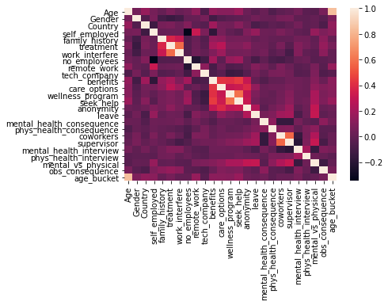

```python
corr = mc_df.iloc[:].corr()
sns.heatmap(corr,
            xticklabels=corr.columns,
            yticklabels=corr.columns)
plt.show()
```

```python
corr["supervisor"]
```

```
Age                          0.003533
Gender                       0.068139
Country                     -0.001308
self_employed                0.037432
family_history               0.003729
treatment                   -0.036199
work_interfere              -0.092664
no_employees                -0.052650
remote_work                  0.025220
tech_company                 0.049543
benefits                     0.039570
care_options                 0.070158
wellness_program             0.103986
seek_help                    0.119302
anonymity                    0.179767
leave                        0.208364
mental_health_consequence   -0.153149
phys_health_consequence      0.103836
coworkers                    0.574310
supervisor                   1.000000
mental_health_interview     -0.189549
phys_health_interview        0.082835
mental_vs_physical           0.311737
obs_consequence             -0.090507
age_bucket                   0.016276
Name: supervisor, dtype: float64
```

```python
res = chi2(mc_df.iloc[:], mc_df['supervisor'])
features = pd.DataFrame({
    'features': mc_df.columns[:],
    'chi2': res[0],
    'p-value': res[1]
})

features
```

|  | features | chi2 | p-value |
| --- | --- | --- | --- |
| 0 | Age | 0.595044 | 7.426564e-01 |
| 1 | Gender | 1.763668 | 4.140229e-01 |
| 2 | Country | 2.950676 | 2.287014e-01 |
| 3 | self_employed | 1.601137 | 4.490735e-01 |
| 4 | family_history | 0.015672 | 9.921946e-01 |
| 5 | treatment | 0.852475 | 6.529614e-01 |
| 6 | work_interfere | 11.234793 | 3.634090e-03 |
| 7 | no_employees | 3.796551 | 1.498267e-01 |
| 8 | remote_work | 2.190844 | 3.343985e-01 |
| 9 | tech_company | 0.576132 | 7.497121e-01 |
| 10 | benefits | 1.925620 | 3.818185e-01 |
| 11 | care_options | 4.552720 | 1.026572e-01 |
| 12 | wellness_program | 11.221737 | 3.657891e-03 |
| 13 | seek_help | 14.367648 | 7.587607e-04 |
| 14 | anonymity | 29.881474 | 3.245789e-07 |
| 15 | leave | 81.879679 | 1.659792e-18 |
| 16 | mental_health_consequence | 42.810801 | 5.055367e-10 |
| 17 | phys_health_consequence | 7.622049 | 2.212550e-02 |
| 18 | coworkers | 164.231691 | 2.175412e-36 |
| 19 | supervisor | 817.150507 | 3.614282e-178 |
| 20 | mental_health_interview | 9.530343 | 8.521428e-03 |
| 21 | phys_health_interview | 6.428747 | 4.018050e-02 |
| 22 | mental_vs_physical | 91.026257 | 1.713560e-20 |
| 23 | obs_consequence | 12.438695 | 1.990544e-03 |
| 24 | age_bucket | 0.330236 | 8.477937e-01 |

### *f) Finalized Hypothesis*

**Null Hypothesis:** Using Random Forest and normalized permutation importance from sklearn, the 5 target predictors are equal to or less than 50% of total feature importance when predicting whether employees are willing to discuss mental health issues with supervisors.

**Alternative Hypothesis:** Using Random Forest and normalized permutation importance from sklearn, the 5 target predictors are greater than 50% of total feature importance when predicting whether employees are willing to discuss mental health issues with supervisors.

**Target Predictors:**

- **leave: How easy is it for you to take medical leave for a mental health condition?**
- benefits: Does your employer provide mental health benefits?
- no_employees: How many employees does your company/organization have?
- obs_consequence: Have you heard of or observed negative consequences for coworkers with mental health conditions in your workplace
- remote_work: Do you work remotely (outside of an office) at least 50% of the time?

## **IV. Initial Model & Feature Engineering**

### *a) Initial Model Plan*

Model:

- Sklearn Library
- Random Forest Model
  - Bootstrapping to create multiple different models from the same dataset

Justification:

Optimization:

- A parameter search algorithm (GridSearchCV) will be used to tune parameters related to tree size, maximum and minimum node size, and number estimators

Training and Testing:

- Data will be randomly split 80% towards training and 20% towards testing

Metrics:

- To test our hypothesis, we will call the permutation feature importance function and measure if the normalized importances for our target predictors sum to greater than or less than 50%
  - Defined to be the decrease in a model score when a single feature value is randomly shuffled Procedure breaks the relationship between the feature and the target, thus the drop in the model score is indicative of how much the model depends on the feature
- We can also compare permutations feature importance with other feature importance metrics if the answer to our hypothesis is unclear

Sources:

- https://scikit-learn.org/stable/modules/permutation_importance.html#relation-to-impurity-based-importance-in-trees

### *b) Encoding Variables*

- all 23 of our categorical variables

```python
df.columns
```

```
Index(['Age', 'Gender', 'Country', 'self_employed', 'family_history',
       'treatment', 'work_interfere', 'no_employees', 'remote_work',
       'tech_company', 'benefits', 'care_options', 'wellness_program',
       'seek_help', 'anonymity', 'leave', 'mental_health_consequence',
       'phys_health_consequence', 'coworkers', 'supervisor',
       'mental_health_interview', 'phys_health_interview',
       'mental_vs_physical', 'obs_consequence', 'age_bucket'],
      dtype='object')
```

```python
encoded_df = pd.get_dummies(df)
encoded_df.head(5)
```

|  | Age | Gender_female | Gender_male | Gender_other | Country_Australia | Country_Austria | Country_Bahamas, The | Country_Belgium | Country_Bosnia and Herzegovina | Country_Brazil | Country_Bulgaria | Country_Canada | Country_China | Country_Colombia | Country_Costa Rica | Country_Croatia | Country_Czech Republic | Country_Denmark | Country_Finland | Country_France | Country_Georgia | Country_Germany | Country_Greece | Country_Hungary | Country_India | Country_Ireland | Country_Israel | Country_Italy | Country_Japan | … |
| --- | --- | --- | --- | --- | --- | --- | --- | --- | --- | --- | --- | --- | --- | --- | --- | --- | --- | --- | --- | --- | --- | --- | --- | --- | --- | --- | --- | --- | --- | --- |
| 0 | 37.0 | 1 | 0 | 0 | 0 | 0 | 0 | 0 | 0 | 0 | 0 | 0 | 0 | 0 | 0 | 0 | 0 | 0 | 0 | 0 | 0 | 0 | 0 | 0 | 0 | 0 | 0 | 0 | 0 | … |
| 1 | 44.0 | 0 | 1 | 0 | 0 | 0 | 0 | 0 | 0 | 0 | 0 | 0 | 0 | 0 | 0 | 0 | 0 | 0 | 0 | 0 | 0 | 0 | 0 | 0 | 0 | 0 | 0 | 0 | 0 | … |
| 2 | 32.0 | 0 | 1 | 0 | 0 | 0 | 0 | 0 | 0 | 0 | 0 | 1 | 0 | 0 | 0 | 0 | 0 | 0 | 0 | 0 | 0 | 0 | 0 | 0 | 0 | 0 | 0 | 0 | 0 | … |
| 3 | 31.0 | 0 | 1 | 0 | 0 | 0 | 0 | 0 | 0 | 0 | 0 | 0 | 0 | 0 | 0 | 0 | 0 | 0 | 0 | 0 | 0 | 0 | 0 | 0 | 0 | 0 | 0 | 0 | 0 | … |
| 4 | 31.0 | 0 | 1 | 0 | 0 | 0 | 0 | 0 | 0 | 0 | 0 | 0 | 0 | 0 | 0 | 0 | 0 | 0 | 0 | 0 | 0 | 0 | 0 | 0 | 0 | 0 | 0 | 0 | 0 | … |

5 rows × 115 columns

### *c) Initial model*

- all 23 of our categorical variables

```python
encoded_df.head(2)
```

|  | Age | Gender_female | Gender_male | Gender_other | Country_Australia | Country_Austria | Country_Bahamas, The | Country_Belgium | Country_Bosnia and Herzegovina | Country_Brazil | Country_Bulgaria | Country_Canada | Country_China | Country_Colombia | Country_Costa Rica | Country_Croatia | Country_Czech Republic | Country_Denmark | Country_Finland | Country_France | Country_Georgia | Country_Germany | Country_Greece | Country_Hungary | Country_India | Country_Ireland | Country_Israel | Country_Italy | Country_Japan | … |
| --- | --- | --- | --- | --- | --- | --- | --- | --- | --- | --- | --- | --- | --- | --- | --- | --- | --- | --- | --- | --- | --- | --- | --- | --- | --- | --- | --- | --- | --- | --- |
| 0 | 37.0 | 1 | 0 | 0 | 0 | 0 | 0 | 0 | 0 | 0 | 0 | 0 | 0 | 0 | 0 | 0 | 0 | 0 | 0 | 0 | 0 | 0 | 0 | 0 | 0 | 0 | 0 | 0 | 0 | … |
| 1 | 44.0 | 0 | 1 | 0 | 0 | 0 | 0 | 0 | 0 | 0 | 0 | 0 | 0 | 0 | 0 | 0 | 0 | 0 | 0 | 0 | 0 | 0 | 0 | 0 | 0 | 0 | 0 | 0 | 0 | … |

2 rows × 115 columns

```python
X = encoded_df.drop(['supervisor_Yes', 'supervisor_No', 'supervisor_Some of them', 'coworkers_Yes', 'coworkers_Some of them', 'coworkers_No', 'Age', 'mental_health_interview_Maybe', 'mental_health_interview_No', 'mental_health_interview_Yes'], axis=1)
y = encoded_df.loc[: ,'supervisor_Yes']
```

```python
print(X.shape)
print(encoded_df.shape)
```

```
(1259, 105)
(1259, 115)
```

```python
#Train, test, split
X_train, X_test, y_train, y_test = train_test_split(
            X,
            y,
            test_size = 0.2,
            random_state = 508)
```

```python
#Instantiate and fit Gini
RF_gini = RandomForestClassifier(n_estimators = 100,
                                     criterion = 'gini',
                                     max_depth = None,
                                     min_samples_leaf = 1,
                                     bootstrap = False,
                                     warm_start = False,
                                     random_state = 508)

#Fitting model
RF_gini_fit = RF_gini.fit(X_train, y_train)

#Printing model scores
print('Training Score', RF_gini_fit.score(X_train, y_train).round(7))
print('Testing Score:', RF_gini_fit.score(X_test, y_test).round(7))
```

```
Training Score 0.9970209
Testing Score: 0.7460317
```

```python
#Instantiate and fit Entropy
RF_entropy = RandomForestClassifier(n_estimators = 100,
                                     criterion = 'entropy',
                                     max_depth = None,
                                     min_samples_leaf = 1,
                                     bootstrap = False,
                                     warm_start = False,
                                     random_state = 508)
RF_entropy_fit = RF_entropy.fit(X_train, y_train)

#Printing model scores
print('Training Score', RF_entropy_fit.score(X_train, y_train).round(7))
print('Testing Score:', RF_entropy_fit.score(X_test, y_test).round(7))
```

```
Training Score 0.9970209
Testing Score: 0.7460317
```

### *d) Plotting Feature Importances*

```python
len(np.sort(RF_entropy_fit.feature_importances_))
```

```
105
```

```python
len(X_train.columns)
```

```
105
```

```python
def plot_feature_importances(model, train = X_train):
    n_features = train.shape[1]
    fi = np.sort(model.feature_importances_) #[::-1]
    fig = px.bar(X_train, fi, y=X_train.columns, orientation='h', title="Feature Importances of Model Features")
    fig.update_layout(xaxis=dict(title="Feature Importance"), yaxis=dict(title="Feature"))
    fig.show()

plot_feature_importances(RF_entropy_fit, train = X_train)
```

[interactive chart not shown]

```python
def plot_n_feature_importances(model, train = X_train, n):
    n_features = train.shape[1]
    fi = np.sort(model.feature_importances_) #[::-1]
    fig = px.bar(X_train, fi, y=X_train.columns, orientation='h', title="Feature Importances of Model Features")
    fig.update_layout(xaxis=dict(title="Feature Importance"), yaxis=dict(title="Feature"))
    fig.show()

plot_n_feature_importances(RF_entropy_fit, train = X_train, 10)
```

[output not shown]

### *e) Label encoded model*

```python
X = mc_df.drop(['supervisor', 'coworkers', 'Age', 'mental_health_interview'], axis=1)
y = mc_df.loc[: ,'supervisor']

#Train, test, split
X_train, X_test, y_train, y_test = train_test_split(
            X,
            y,
            test_size = 0.2,
            random_state = 508)
```

```python
#Instantiate and fit Entropy
RF_entropy = RandomForestClassifier(n_estimators = 100,
                                     criterion = 'entropy',
                                     max_depth = None,
                                     min_samples_leaf = 1,
                                     bootstrap = False,
                                     warm_start = False,
                                     random_state = 508)
RF_entropy_fit = RF_entropy.fit(X_train, y_train)

#Printing model scores
print('Training Score', RF_entropy_fit.score(X_train, y_train).round(7))
print('Testing Score:', RF_entropy_fit.score(X_test, y_test).round(7))
```

```
Training Score 0.9970209
Testing Score: 0.5833333
```

```python
plot_feature_importances(RF_entropy_fit, train = X_train)
```

[interactive chart not shown]

## **VII. References**

1. NIMH » Mental Illness. Accessed January 6, 2021. https://www.nimh.nih.gov/health/statistics/mental-illness.shtml
1. Depression. Accessed January 6, 2021. https://www.who.int/en/news-room/fact-sheets/detail/depression
1. Mental Health By the Numbers | NAMI: National Alliance on Mental Illness. Accessed January 6, 2021. https://www.nami.org/mhstats
1. Fuhrer R, Keyes KM. Population Mental Health in the 21st Century: Time to Act. Am J Public Health. 2019;109(Suppl 3):S152-S153. doi:10.2105/AJPH.2019.305200
1. Pescosolido BA. The Public Stigma of Mental Illness: What Do We Think; What Do We Know; What Can We Prove? J Health Soc Behav. 2013;54(1):1-21. doi:10.1177/0022146512471197
1. Oexle N, Müller M, Kawohl W, et al. Self-stigma as a barrier to recovery: a longitudinal study. Eur Arch Psychiatry Clin Neurosci. 2018;268(2):209-212. doi:10.1007/s00406-017-0773-2
1. Mental health: Why is it hard to talk about problems? - CBBC Newsround.https://www.bbc.co.uk/newsround/46425575. Accessed January 6, 2021.
1. Disability in the Workplace: A Unique and Variable Identity - Alecia M. Santuzzi, Pamela R. Waltz, 2016. Accessed January 6, 2021. https://journals.sagepub.com/doi/full/10.1177/0149206315626269
1. Mental Health in the Workplace. Published April 26, 2019. Accessed January 6, 2021. https://www.cdc.gov/workplacehealthpromotion/tools-resources/workplace-health/mental-health/index.html
1. COVID-19’s Impact on Mental Health and Workplace Well-being. NIHCM. Accessed January 6, 2021. https://nihcm.org/publications/covid-19s-impact-on-mental-health-and-workplace-well-being
1. Mental illness - Symptoms and causes. Mayo Clinic. Accessed January 6, 2021. https://www.mayoclinic.org/diseases-conditions/mental-illness/symptoms-causes/syc-20374968
1. Parcesepe AM, Cabassa LJ. Public Stigma of Mental Illness in the United States: A Systematic Literature Review. Adm Policy Ment Health. 2013;40(5). doi:10.1007/s10488-012-0430-z
1. Agovino T, Agovino T. Mental Illness and the Workplace. SHRM. Published August 3, 2019. Accessed January 6, 2021. https://www.shrm.org/hr-today/news/all-things-work/pages/mental-illness-and-the-workplace.aspx
1. Four Ways Culture Impacts Mental Health. Mental Health First Aid. Published July 11, 2019. Accessed January 6, 2021. https://www.mentalhealthfirstaid.org/2019/07/four-ways-culture-impacts-mental-health/
1. Rathore S. Tech Industry Sees Major Growth in New Companies During 2019. Small Business Trends. Published March 5, 2020. Accessed January 6, 2021. https://smallbiztrends.com/2020/03/2019-industry-growth-statistics.html
1. Sado M, Shirahase J, Yoshimura K, et al. Predictors of repeated sick leave in the workplace because of mental disorders. Neuropsychiatr Dis Treat. 2014;10:193-200. doi:10.2147/NDT.S55490
1. Publishing HH. Mental health problems in the workplace. Harvard Health. Accessed January 6, 2021. https://www.health.harvard.edu/newsletter_article/mental-health-problems-in-the-workplace
1. Workplace Mental Health - Working Remotely During COVID-19. Accessed January 6, 2021. http://www.workplacementalhealth.org/Employer-Resources/Working-Remotely-During-COVID-19
1. OSMI Home :: Open Sourcing Mental Illness - Changing how we talk about mental health in the tech community - Stronger Than Fear. Accessed January 7, 2021. https://osmihelp.org/
1. Mental Health in Tech Survey. Accessed January 6, 2021. https://kaggle.com/osmi/mental-health-in-tech-survey